# 12 RE4 Experimental Design

ECON 474 Econometrics of Policy Evaluation

Almost all economic analaysis, whether regression or theory-based uses the t-statistic as the statistical test. In regression, that corresponds to significance test on a coefficient on treatment. Therefore, our object of interest when designing an experiment is the t-statistic on said coefficient:

$$t_{\hat{\beta}_{T}}^* =
\frac{\hat{\beta}_T - \beta_T}{se(\hat{\beta}_T)}$$

where $\beta_T$ is the null hypothesis value, which is almost exclusively set to $\beta_T = 0$ in practice. Consequently, we will be focusing on having a large t-stat effect size in the `pwr` package.

Speaking of which, let’s load it in along with the `tidyverse`:

```r
install.packages(pwr)
```

```r
library(pwr)
library(tidyverse)
```

# 1 The `pwr` Package

There are many kinds of power tests that can be run using the `pwr` package:

```r
help(package = 'pwr')
```

However, we are going to focus on the two t-test functions

## 1.1 Basic Implementation

One way to boil down econometrics is trying to measure effects, where some effects are larger than others. While a somewhat subjective pursuit, [Cohen (1988)](https://www.taylorfrancis.com/books/mono/10.4324/9780203771587/statistical-power-analysis-behavioral-sciences-jacob-cohen) put together some rules of thumb for us for small, medium, and large effect sizes for various tests. This is exactly what the package `pwr` uses to help with experimental design.

Since we will be performing a t-test, we can determine the size of $t_{\hat{\beta}_{T}}^*$ we need using `cohen.ES()`. The first argument of this function is `test`, and the second is `size`. See `?cohen.ES` for more details. So what does Dr. Cohen consider to be a *small* effect size for a t-test?

```r
cohen.ES(test = 't', size = 'small')
```

```
##
##      Conventional effect size from Cohen (1982)
##
##            test = t
##            size = small
##     effect.size = 0.2
```

This corresponds to:

$$0.2 = t^* = \frac{\hat{\beta} -
\beta_{H_0}}{se(\hat{\beta})}$$

What about a large effect size?

```r
cohen.ES(test = 't', size = 'large')
```

```
##
##      Conventional effect size from Cohen (1982)
##
##            test = t
##            size = large
##     effect.size = 0.8
```

Each `pwr.XX.test()` function has the same four arguments:

1. sample size
2. effect size
3. significance level
4. power of test

The functions are designed to leave one of the arguments empty and solve for it using the other three specified arguments.

We are going to specify the effect size, significance level, and the power to determine the sample side which we need. Intuitively, we want to specify how confident we are in our test to know whether or not our estimates are true. We also want to specify the effect size to something conservative (small), so that way we can be sure to detect it. Then we can know the minimum sample size that we need to be sure of whether or not there is an affect.

Experiments are costly to run in terms of time and money. Moreover, you might not get the opportunity to run your experiment again even if your results are noisy from too small of a sample. You want to make sure you get it right the first time.

For the `pwr.t.test()` function, we also need to specify two additional arguments:

5. the `type` of t-test
6. the `alternative` hypothesis type

Because randomized experiments have a control group **and** a treatment group, the type of test (5.) is `"two.sample"`. Since the results are almost exclusively analysed in a regression and since no one seems to specify anything other than the default alternative hypothesis, the `alternative` is set to `"two.sided"`.

Here’s how to do implement the power analysis to determine the sample size using a small effect size with the conventional 95% confidence and 0.8 probability of rejecting a false null hypothesis:

```r
pwr.t.test(d = 0.2,
           sig.level = 0.05,
           power = 0.8,
           type = 'two.sample',
           alternative = 'two.side')
```

```
##
##      Two-sample t test power calculation
##
##               n = 393.4057
##               d = 0.2
##       sig.level = 0.05
##           power = 0.8
##     alternative = two.sided
##
## NOTE: n is number in *each* group
```

This test would require 394 people in the treatment group and another 394 in the control group. To be clear, we would need a total of 788 people in the experiment!

Now suppose we are in a situation where it is costly to treat individuals, so we are limited to only treating 200 people. What size does our control group need to be? We can determine this by using the function `pwr.t2n.test()` and set the argument `n1 = 200`. Note that this question is inherently a two-sample design, so that is the underlying type of test in `pwr.t2n.test()`.

```r
pwr.t2n.test(n1 = 200,
             d = 0.2,
           sig.level = 0.05,
           power = 0.8)
```

```
##
##      t test power calculation
##
##              n1 = 200
##              n2 = 10486.03
##               d = 0.2
##       sig.level = 0.05
##           power = 0.8
##     alternative = two.sided
```

Holy cow! 10,487 people in the control group!

## 1.2 Sample Size and Power Relationship

```r
d = seq(0.2, 0.8, length = 100)
n2 = NULL # a placeholder for our results
for(d_i in d){
  pwr_test = pwr.t2n.test(n1 = 200,
                          d = d_i,
                          sig.level = 0.05,
                          power = 0.8,
                          alternative = 'two.sided')
  n2 = c(n2, pwr_test$n2)
}

df_plot = tibble(`Effect Size` = d,
                 `Control Group Size` = n2)
```

Now let’s take a look at those results!

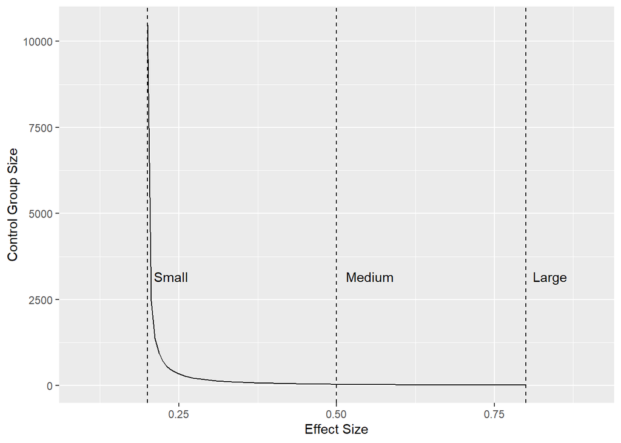

```r
ggplot(df_plot, aes(x = `Effect Size`, y = `Control Group Size`)) +
  geom_line() +
  geom_vline(xintercept = c(0.2, 0.5, 0.8), linetype = 'dashed') +
  annotate("text", x = c(0.2, 0.5, 0.8), y = 10^3.5,
           label = c('Small', 'Medium', 'Large'), hjust = -0.2) +
  xlim(0.1, 0.9)
```

For funsies, let’s look at this figure with a log10 transformation of the y-axis.

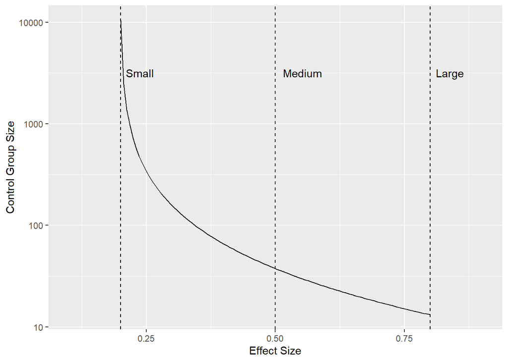

```r
ggplot(df_plot, aes(x = `Effect Size`, y = `Control Group Size`)) +
  geom_line() +
  scale_y_continuous(trans = 'log10') +
  geom_vline(xintercept = c(0.2, 0.5, 0.8), linetype = 'dashed') +
  annotate("text", x = c(0.2, 0.5, 0.8), y = 10^3.5,
           label = c('Small', 'Medium', 'Large'), hjust = -0.2) +
  xlim(0.1, 0.9)
```

# 2 Lab - Thornton 2008

We will work with the data from Thornton 2008 for the lab and will make some simplifying assumptions to work with the `pwr` package. To begin:

1. Load in the data `Thornton 2008 main sample.csv` as `df`
2. `mutate()` a new variable called `incentive` using `ifelse()` or `case_when()` such that when `any == 1` it equals `"incentive"` and `"no incentive"` otherwise.

```r
df = read_csv('C:/Users/johnj/Dropbox/Julian/Academia/UIUC/Semester 11 Fall 2022/ECON474/Data/Thornton 2008 main sample.csv')
df = df %>%
  mutate(incentive = ifelse(any == 1, 'incentive', 'no incentive'))
```

## 2.1 Possible Sample Design (post-results)

Suppose the sample estimates from the experiment are the true population coefficients. Create an object `eff_size` that is equal to the effect size of this experiment. In this case we will plug in to the t-test:

$$H_0: \beta = \beta_{\text{no
incentive}}$$

Specifically,

1. perform a regression of `got` on `incentive` without an intercept term by add `-1` to the formula and save it as an object called `fit`
2. print a summary of the regression
3. save the vector of coefficients as `b` using the function `coef()` wrapped around `fit`
   - this vector contains the estimated coefficient and the null hypothesis coefficient
4. estimate the standard deviation by using the function `sd()` on the variable `any`
5. use the t-statistic formula to estimate the “true” effect size and save it as `eff_size`

```r
fit = lm(got ~ incentive - 1, data = df)
summary(fit)
```

```
##
## Call:
## lm(formula = got ~ incentive - 1, data = df)
##
## Residuals:
##     Min      1Q  Median      3Q     Max
## -0.7908 -0.3414  0.2092  0.2092  0.6586
##
## Coefficients:
##                       Estimate Std. Error t value Pr(>|t|)
## incentiveincentive    0.790793   0.009023   87.64   <2e-16 ***
## incentiveno incentive 0.341424   0.017001   20.08   <2e-16 ***
## ---
## Signif. codes:  0 '***' 0.001 '**' 0.01 '*' 0.05 '.' 0.1 ' ' 1
##
## Residual standard error: 0.4226 on 2810 degrees of freedom
## Multiple R-squared:  0.7421, Adjusted R-squared:  0.7419
## F-statistic:  4042 on 2 and 2810 DF,  p-value: < 2.2e-16
```

```r
b = coef(fit)
sd = sd(df$any)

eff_size = (b[1] - b[2])/sd
```

Assume that the control and treatment groups have the same size. Using the appropriate function from the `pwr` function, determine the total sample size using the “true” effect size calculated above, a significance level of 0.05, a power level of 0.8, and an alternative of `"greater"`.

```r
pwr.t.test(d = eff_size,
             sig.level = 0.05,
             power = 0.8,
             type = 'two.sample', # b/c treatment and control groups
             alternative = "greater")
```

```
##
##      Two-sample t test power calculation
##
##               n = 11.24636
##               d = 1.084998
##       sig.level = 0.05
##           power = 0.8
##     alternative = greater
##
## NOTE: n is number in *each* group
```

How and to what do the number of observations required change to when the alternative is specified as a two-sided test?

```r
pwr.t.test(d = eff_size,
             sig.level = 0.05,
             power = 0.8,
             type = 'two.sample', # b/c treatment and control groups
             alternative = "two.sided")
```

```
##
##      Two-sample t test power calculation
##
##               n = 14.36134
##               d = 1.084998
##       sig.level = 0.05
##           power = 0.8
##     alternative = two.sided
##
## NOTE: n is number in *each* group
```

## 2.2 Minimum Sample Size (pre-results)

Now, suppose we are in the world before the randomized experiment was conducted. Let’s put ourselves in Dr. Thornton’s shoes and try to deduce what she might have been aiming for when designing her experiment. Given the number of observations, use `pwr.t.test()` to determine the significance level and power she may have been aiming for with a small treatment effect

To do set:

1. set `d` to a small treatment effect
2. set `type` to two sample test
3. set `alternative` to a two sided test
4. try `sig.level` over values of 0.05, 0.01, and 0.001
5. try `power` over values 0.8, 0.9, 0.99

```r
nrow(df)
```

```
## [1] 2812
```

```r
cohen.ES(test = 't', size = 'small')
```

```
##
##      Conventional effect size from Cohen (1982)
##
##            test = t
##            size = small
##     effect.size = 0.2
```

```r
grid = expand.grid(d = 0.2,
            sig.level = c(0.05, 0.01, 0.001),
            power = c(0.8, 0.9, 0.99),
            n = NA)

for(i in 1:nrow(grid)){
  grid$n[i] = ceiling(
    pwr.t.test(d = grid$d[i],
               sig.level = grid$sig.level[i],
               power = grid$power[i],
               type = 'two.sample',
               alternative = 'two.sided')$n
  )*2
}
grid %>%
  arrange(desc(n))
```

```
##     d sig.level power    n
## 1 0.2     0.001  0.99 3162
## 2 0.2     0.010  0.99 2408
## 3 0.2     0.001  0.90 2096
## 4 0.2     0.050  0.99 1840
## 5 0.2     0.001  0.80 1714
## 6 0.2     0.010  0.90 1492
## 7 0.2     0.010  0.80 1172
## 8 0.2     0.050  0.90 1054
## 9 0.2     0.050  0.80  788
```